# Week7

Shrey Kothari

2025-11-14

```r
library(tidyverse)
data <- read_csv("~/cox-violent-parsed.csv")
```

```
## ──────────────────────────────────────────────────────── Delimiter: "," chr
## (33): name, first, last, compas_screening_date, sex, dob, age_cat, race,... dbl
## (18): id, age, juv_fel_count, decile_score...12, juv_misd_count, juv_oth... lgl
## (1): violent_recid
```

```r
set.seed(862331611)
rows <- nrow(data)
trainIndex <- sample(1:rows, size = 0.7*rows)
trainData <- data[trainIndex, ]
testData <- data[-trainIndex, ]
trainData <- trainData %>%
  rename(priors_count = priors_count...15)
testData <- testData %>%
  rename(priors_count = priors_count...15)
trainData <- trainData %>%
  rename(decile_score = decile_score...12)
testData <- testData %>%
  rename(decile_score = decile_score...12)
```

Step 1:

```r
variablesOfInterest <- c("is_recid", "race", "age", "priors_count", "juv_fel_count", "decile_score")
df <- trainData[, variablesOfInterest]
model <- lm(is_recid ~ race + juv_fel_count + age + priors_count, data = df)
summary(model)
```

```
##
## Call:
## lm(formula = is_recid ~ race + juv_fel_count + age + priors_count,
##     data = df)
##
## Residuals:
##     Min      1Q  Median      3Q     Max
## -1.5146 -0.3983 -0.1171  0.5257  1.3468
##
## Coefficients:
##                       Estimate Std. Error t value Pr(>|t|)
## (Intercept)          0.6324645  0.0149336  42.352  < 2e-16 ***
## raceAsian           -0.2232139  0.0788232  -2.832  0.00464 **
## raceCaucasian       -0.0072905  0.0109023  -0.669  0.50369
## raceHispanic        -0.0932249  0.0183022  -5.094 3.56e-07 ***
## raceNative American -0.0836066  0.0874835  -0.956  0.33925
## raceOther           -0.0198302  0.0232632  -0.852  0.39399
## juv_fel_count        0.0094308  0.0101044   0.933  0.35066
## age                 -0.0099461  0.0004246 -23.423  < 2e-16 ***
## priors_count         0.0343936  0.0009610  35.788  < 2e-16 ***
## ---
## Signif. codes:  0 '***' 0.001 '**' 0.01 '*' 0.05 '.' 0.1 ' ' 1
##
## Residual standard error: 0.5377 on 12812 degrees of freedom
## Multiple R-squared:  0.1258, Adjusted R-squared:  0.1253
## F-statistic: 230.5 on 8 and 12812 DF,  p-value: < 2.2e-16
```

Step 2:

```r
cor(df[, c("is_recid", "age", "priors_count", "decile_score")], use = "complete.obs")
```

```
##                is_recid        age priors_count decile_score
## is_recid      1.0000000 -0.1491004    0.2865658    0.2766166
## age          -0.1491004  1.0000000    0.1774344   -0.3652360
## priors_count  0.2865658  0.1774344    1.0000000    0.4125753
## decile_score  0.2766166 -0.3652360    0.4125753    1.0000000
```

```r
car::vif(model)
```

```
##                   GVIF Df GVIF^(1/(2*Df))
## race          1.100889  5        1.009658
## juv_fel_count 1.042596  1        1.021076
## age           1.091036  1        1.044527
## priors_count  1.135328  1        1.065518
```

There are no variables with VIF that is greater than 5. We do not have redundant information.

```r
model2 <- lm(is_recid ~ race + juv_fel_count + age + priors_count + decile_score, data = df)
summary(model2)
```

```
##
## Call:
## lm(formula = is_recid ~ race + juv_fel_count + age + priors_count +
##     decile_score, data = df)
##
## Residuals:
##     Min      1Q  Median      3Q     Max
## -1.5262 -0.3845 -0.1047  0.5045  1.2505
##
## Coefficients:
##                       Estimate Std. Error t value Pr(>|t|)
## (Intercept)          0.4690088  0.0222794  21.051  < 2e-16 ***
## raceAsian           -0.1909657  0.0785972  -2.430 0.015126 *
## raceCaucasian        0.0070139  0.0109581   0.640 0.522141
## raceHispanic        -0.0705612  0.0183783  -3.839 0.000124 ***
## raceNative American -0.0735624  0.0871630  -0.844 0.398705
## raceOther            0.0154399  0.0234510   0.658 0.510300
## juv_fel_count       -0.0001634  0.0101137  -0.016 0.987111
## age                 -0.0077999  0.0004758 -16.393  < 2e-16 ***
## priors_count         0.0293666  0.0010848  27.070  < 2e-16 ***
## decile_score         0.0205408  0.0020840   9.856  < 2e-16 ***
## ---
## Signif. codes:  0 '***' 0.001 '**' 0.01 '*' 0.05 '.' 0.1 ' ' 1
##
## Residual standard error: 0.5357 on 12811 degrees of freedom
## Multiple R-squared:  0.1324, Adjusted R-squared:  0.1318
## F-statistic: 217.2 on 9 and 12811 DF,  p-value: < 2.2e-16
```

Step 3:

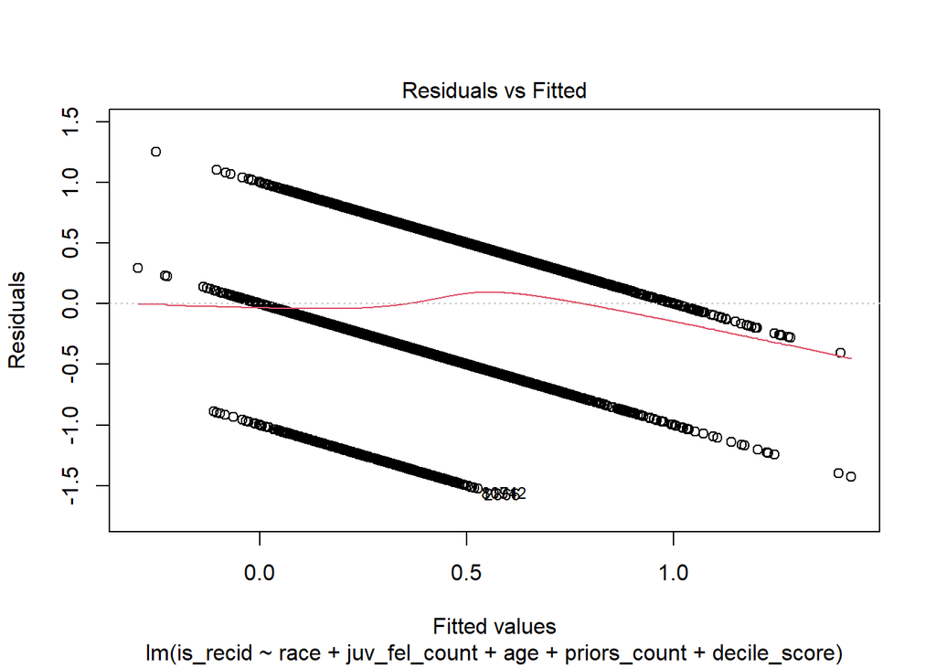

```r
plot(model2, which = 1)
```

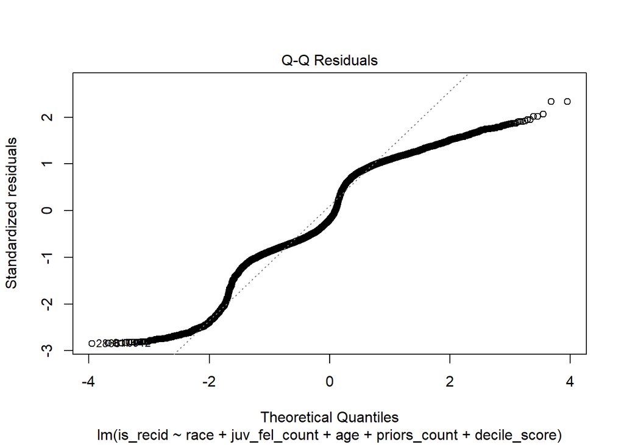

```r
plot(model2, which = 2)
```

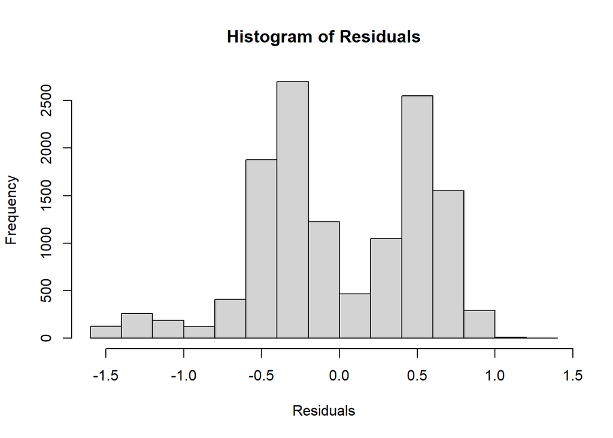

```r
histogram <- hist(residuals(model2), main = "Histogram of Residuals", xlab = "Residuals")
```

```r
histogram
```

```
## $breaks
##  [1] -1.6 -1.4 -1.2 -1.0 -0.8 -0.6 -0.4 -0.2  0.0  0.2  0.4  0.6  0.8  1.0  1.2
## [16]  1.4
##
## $counts
##  [1]  127  258  188  119  411 1878 2695 1222  468 1049 2548 1549  295   12    2
##
## $density
##  [1] 0.0495281179 0.1006161766 0.0733172139 0.0464082365 0.1602839092
##  [6] 0.7323921691 1.0510100616 0.4765618906 0.1825130645 0.4090944544
## [11] 0.9936822401 0.6040870447 0.1150456283 0.0046798222 0.0007799704
##
## $mids
##  [1] -1.5 -1.3 -1.1 -0.9 -0.7 -0.5 -0.3 -0.1  0.1  0.3  0.5  0.7  0.9  1.1  1.3
##
## $xname
## [1] "residuals(model2)"
##
## $equidist
## [1] TRUE
##
## attr(,"class")
## [1] "histogram"
```

We see patterns of heteroscedasticity in the Residuals vs Fitted graph because we see three bands. This is because the response variable, is_recid, is a binary variable. We do see extreme outliers, such as the dot on the right side of the bottom line in the Residuals vs Fitted graph.

From the graphs, many of the assumptions have not been satisfied. Constant variance is violated because we have strong heteroscedasticity patterns. Linearity is violted because our outcome is binary. The residual are not normally distributed because we see an S shape in the QQ plot with heavy deviation from the line.

Step 4:

```r
pred_test <- predict(model2, newdata = testData)
RMSE <- sqrt(mean((testData$is_recid - pred_test)^2))
RMSE
```

```
## [1] 0.5411531
```

```r
summary(model2)
```

```
##
## Call:
## lm(formula = is_recid ~ race + juv_fel_count + age + priors_count +
##     decile_score, data = df)
##
## Residuals:
##     Min      1Q  Median      3Q     Max
## -1.5262 -0.3845 -0.1047  0.5045  1.2505
##
## Coefficients:
##                       Estimate Std. Error t value Pr(>|t|)
## (Intercept)          0.4690088  0.0222794  21.051  < 2e-16 ***
## raceAsian           -0.1909657  0.0785972  -2.430 0.015126 *
## raceCaucasian        0.0070139  0.0109581   0.640 0.522141
## raceHispanic        -0.0705612  0.0183783  -3.839 0.000124 ***
## raceNative American -0.0735624  0.0871630  -0.844 0.398705
## raceOther            0.0154399  0.0234510   0.658 0.510300
## juv_fel_count       -0.0001634  0.0101137  -0.016 0.987111
## age                 -0.0077999  0.0004758 -16.393  < 2e-16 ***
## priors_count         0.0293666  0.0010848  27.070  < 2e-16 ***
## decile_score         0.0205408  0.0020840   9.856  < 2e-16 ***
## ---
## Signif. codes:  0 '***' 0.001 '**' 0.01 '*' 0.05 '.' 0.1 ' ' 1
##
## Residual standard error: 0.5357 on 12811 degrees of freedom
## Multiple R-squared:  0.1324, Adjusted R-squared:  0.1318
## F-statistic: 217.2 on 9 and 12811 DF,  p-value: < 2.2e-16
```

Our RMSE (testing) is equal to 0.5411 while R^2 (training) is equal to 0.1324 This tells me that the model would perform poorly and has limited generalizability.

This is the sign of underfitting because we are performing poorly in both the training and testing sets.